# Simultaneous count model vignette

### Fit our model

This is a short-run test fit, with just 5000 iterations.

```
Inference for Bugs model at "D:\Users\ryan\AppData\Local\Temp\RtmpwXBkRl\filefa075035089", fit using jags,
 3 chains, each with 5000 iterations (first 100 discarded), n.thin = 4
 n.sims = 3675 iterations saved
          mu.vect sd.vect     2.5%      25%      50%      75%    97.5%  Rhat n.eff
N         623.100  22.414  590.000  602.000  626.000  636.000  682.000 1.520     8
lambda    623.438  33.556  560.754  600.022  622.965  645.199  691.448 1.196    15
pi[1]       0.016   0.001    0.014    0.015    0.016    0.017    0.018 1.059   130
pi[2]       0.241   0.010    0.223    0.237    0.242    0.250    0.259 1.661     6
pi[3]       0.062   0.003    0.055    0.061    0.062    0.063    0.066 1.207    19
pi[4]       0.353   0.013    0.321    0.345    0.349    0.364    0.378 1.454     8
pi[5]       0.131   0.006    0.118    0.127    0.130    0.137    0.140 1.411     9
pi[6]       0.197   0.029    0.153    0.167    0.202    0.209    0.267 1.587     7
deviance 1075.980   7.957 1063.426 1070.355 1074.338 1081.477 1090.652 1.317    10

For each parameter, n.eff is a crude measure of effective sample size,
and Rhat is the potential scale reduction factor (at convergence, Rhat=1).

DIC info (using the rule, pD = var(deviance)/2)
pD = 24.8 and DIC = 1100.8
DIC is an estimate of expected predictive error (lower deviance is better).
```

The high R-hat values suggest the model is not converged.

Let’s also check the traceplots.

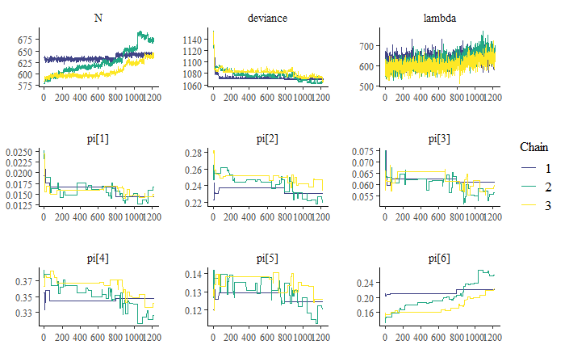

```r
color_scheme_set(scheme = "viridis")
mcmc_trace(x = jags.fit$BUGSoutput$sims.array)
```

These are clearly not converged.

Let’s try fitting with a much longer run and burn-in. Generally this might be done iteratively, but let’s go straight to 300k iterations with 100k burn-in.

We also use `jags.parallel` here to fit chains in parallel.

```r
jags.fit <- do.call(
  what = jags.parallel,
  args = list(
    data = jags.data,
  inits = jags.inits,
  parameters.to.save = jags.params,
  n.iter = 300000,
  n.burnin = 100000,
  n.chains = 3,
  n.thin = 100,
  model.file = jags.mod
  )
)
```

```
Inference for Bugs model at "D:\Users\ryan\AppData\Local\Temp\RtmpwXBkRl\filefa075035089", fit using jags,
 3 chains, each with 3e+05 iterations (first 1e+05 discarded), n.thin = 100
 n.sims = 6000 iterations saved
          mu.vect sd.vect     2.5%      25%      50%      75%    97.5%  Rhat n.eff
N        1046.889 228.312  752.975  887.000  997.000 1153.000 1661.050 1.012   200
lambda   1047.262 230.544  746.132  886.918  997.805 1157.047 1659.316 1.011   200
pi[1]       0.010   0.002    0.006    0.008    0.010    0.011    0.013 1.011   200
pi[2]       0.150   0.028    0.091    0.131    0.152    0.170    0.202 1.011   200
pi[3]       0.037   0.007    0.023    0.033    0.038    0.043    0.050 1.011   200
pi[4]       0.218   0.040    0.132    0.190    0.220    0.247    0.291 1.011   200
pi[5]       0.081   0.015    0.048    0.070    0.081    0.091    0.108 1.012   200
pi[6]       0.504   0.092    0.337    0.437    0.500    0.568    0.700 1.012   180
deviance 1053.474   3.470 1048.578 1050.933 1052.834 1055.376 1061.920 1.002  2200

For each parameter, n.eff is a crude measure of effective sample size,
and Rhat is the potential scale reduction factor (at convergence, Rhat=1).

DIC info (using the rule, pD = var(deviance)/2)
pD = 6.0 and DIC = 1059.5
DIC is an estimate of expected predictive error (lower deviance is better).
```

These R-hat values are much better (<1.1).

Let’s also see some traceplots.

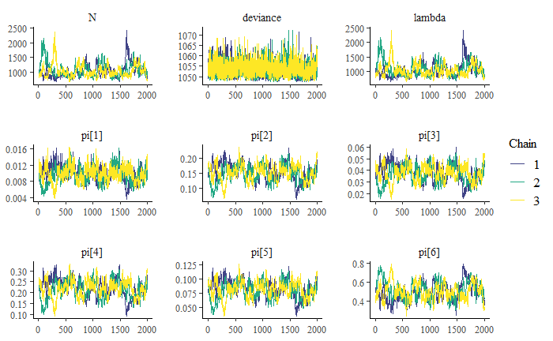

```r
mcmc_trace(x = jags.fit$BUGSoutput$sims.array)
```

Showing a lot of autocorrelation, but appear to be converged.

## Results

Let’s have a look at our results.

Yellow points represent the posterior median, dark purple bands the 50% credible interval, and light blue bands the 95% credible interval.

Our estimates of *pi*:

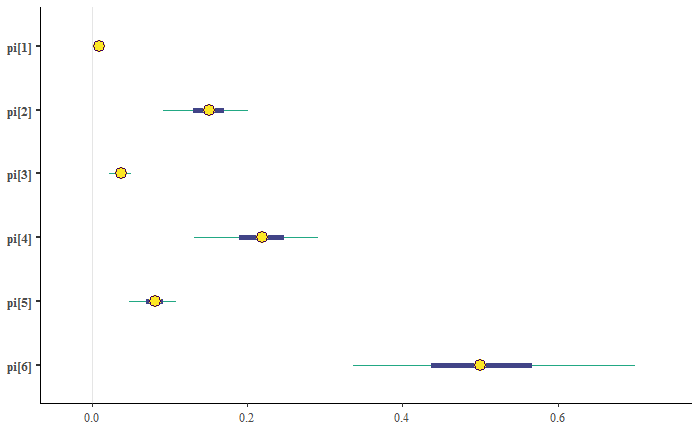

```r
mcmc_intervals(
  x = jags.fit$BUGSoutput$sims.array,
  pars = sprintf("pi[%s]", 1:6),
  prob_outer = 0.95
)
```

And of *N*:

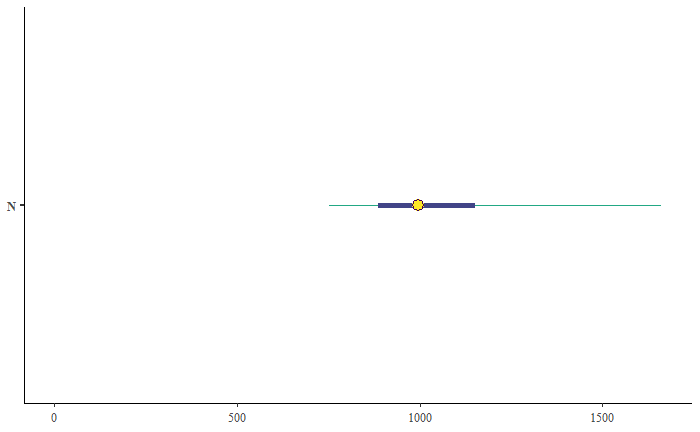

```r
mcmc_intervals(
  x =jags.fit$BUGSoutput$sims.array,
  pars = "N",
  prob_outer = 0.95
) +
  scale_x_continuous(limits = c(0, NA))
```

And let’s compare these directly with our true values. Here the red box and cross represent our true value, plotted over our posterior estimates.

*Pi*:

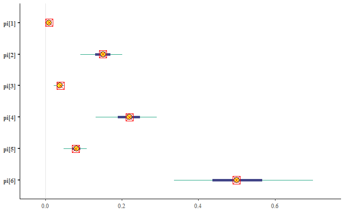

```r
true.pi <- data.frame(
  x = probs,
  y = sprintf("pi[%s]", 1:6)
)

mcmc_intervals(
  x = jags.fit$BUGSoutput$sims.array,
  pars = sprintf("pi[%s]", 1:6),
  prob_outer = 0.95
) +
  geom_point(
    data = true.pi,
    aes(
      x = x,
      y = y
    ),
    shape = 7,
    col = "red",
    size = 5
  )
```

Lookds pretty good!

And of *N*:

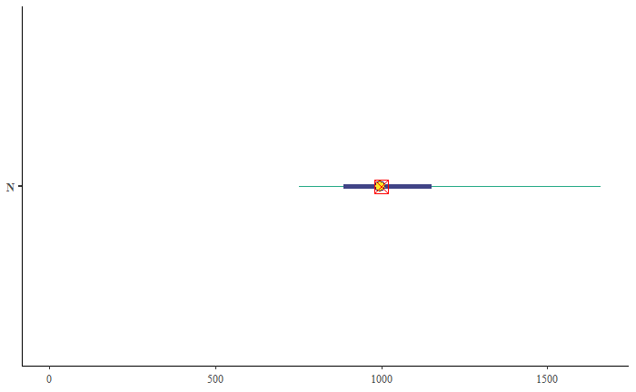

```r
true.N <- data.frame(
  x = population.size,
  y = "N"
)

mcmc_intervals(
  x =jags.fit$BUGSoutput$sims.array,
  pars = "N",
  prob_outer = 0.95
) +
  scale_x_continuous(limits = c(0, NA)) +
  geom_point(
    data = true.N,
    aes(
      x = x,
      y = y
    ),
    shape = 7,
    col = "red",
    size = 5
  )
```

Not too bad.